# Risk Factor Analysis

## Outcome Variable

**Outcome Variable:** ever_stunted

## Predictor Variables

**Intervention Variable:** vagbrth

**Adjustment Set:**

unadjusted

## Stratifying Variables

The analysis was stratified on these variable(s):

- agecat
- studyid

The following strata were considered:

- agecat: 12 months, studyid: ki1000108-CMC-V-BCS-2002
- agecat: 12 months, studyid: ki1000108-IRC
- agecat: 12 months, studyid: ki1017093c-NIH-Crypto
- agecat: 12 months, studyid: ki1066203-TanzaniaChild2
- agecat: 12 months, studyid: ki1119695-PROBIT
- agecat: 12 months, studyid: ki1126311-ZVITAMBO
- agecat: 12 months, studyid: kiGH5241-JiVitA-3
- agecat: 12 months, studyid: kiGH5241-JiVitA-4
- agecat: 18 months, studyid: ki1000108-CMC-V-BCS-2002
- agecat: 18 months, studyid: ki1000108-IRC
- agecat: 18 months, studyid: ki1017093c-NIH-Crypto
- agecat: 18 months, studyid: ki1066203-TanzaniaChild2
- agecat: 18 months, studyid: ki1119695-PROBIT
- agecat: 18 months, studyid: ki1126311-ZVITAMBO
- agecat: 18 months, studyid: kiGH5241-JiVitA-3
- agecat: 18 months, studyid: kiGH5241-JiVitA-4
- agecat: 24 months, studyid: ki1000108-CMC-V-BCS-2002
- agecat: 24 months, studyid: ki1000108-IRC
- agecat: 24 months, studyid: ki1017093c-NIH-Crypto
- agecat: 24 months, studyid: ki1066203-TanzaniaChild2
- agecat: 24 months, studyid: ki1119695-PROBIT
- agecat: 24 months, studyid: ki1126311-ZVITAMBO
- agecat: 24 months, studyid: kiGH5241-JiVitA-3
- agecat: 24 months, studyid: kiGH5241-JiVitA-4
- agecat: 3 months, studyid: ki1000108-CMC-V-BCS-2002
- agecat: 3 months, studyid: ki1000108-IRC
- agecat: 3 months, studyid: ki1017093c-NIH-Crypto
- agecat: 3 months, studyid: ki1066203-TanzaniaChild2
- agecat: 3 months, studyid: ki1119695-PROBIT
- agecat: 3 months, studyid: ki1126311-ZVITAMBO
- agecat: 3 months, studyid: kiGH5241-JiVitA-3
- agecat: 3 months, studyid: kiGH5241-JiVitA-4
- agecat: 6 months, studyid: ki1000108-CMC-V-BCS-2002
- agecat: 6 months, studyid: ki1000108-IRC
- agecat: 6 months, studyid: ki1017093c-NIH-Crypto
- agecat: 6 months, studyid: ki1066203-TanzaniaChild2
- agecat: 6 months, studyid: ki1119695-PROBIT
- agecat: 6 months, studyid: ki1126311-ZVITAMBO
- agecat: 6 months, studyid: kiGH5241-JiVitA-3
- agecat: 6 months, studyid: kiGH5241-JiVitA-4

### Dropped Strata

Some strata were dropped due to rare outcomes:

- agecat: 18 months, studyid: ki1000108-CMC-V-BCS-2002
- agecat: 24 months, studyid: ki1000108-CMC-V-BCS-2002
- agecat: 24 months, studyid: kiGH5241-JiVitA-3

# Results Detail

## Results Plots

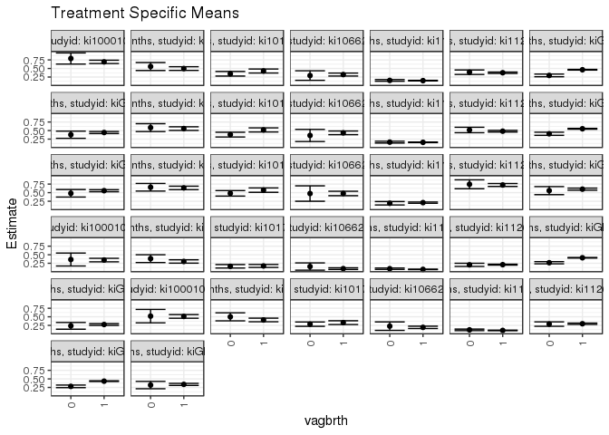

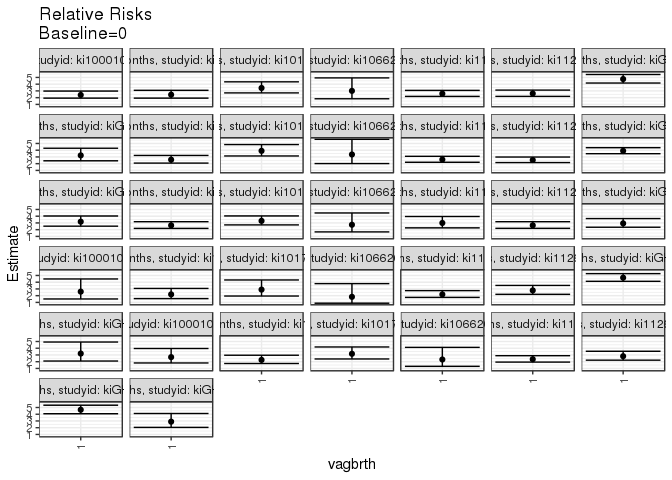

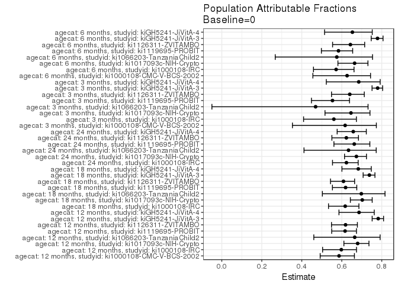

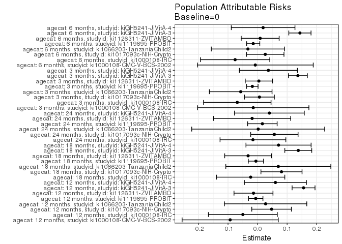

## Data Summary

| agecat | studyid | A | n | nA | nAY0 | nAY1 |
| --- | --- | --- | --- | --- | --- | --- |
| 12 months | ki1000108-CMC-V-BCS-2002 | 0 | 372 | 24 | 5 | 19 |
| 12 months | ki1000108-CMC-V-BCS-2002 | 1 | 372 | 348 | 107 | 241 |
| 12 months | ki1000108-IRC | 0 | 408 | 70 | 31 | 39 |
| 12 months | ki1000108-IRC | 1 | 408 | 338 | 170 | 168 |
| 12 months | ki1017093c-NIH-Crypto | 0 | 471 | 194 | 127 | 67 |
| 12 months | ki1017093c-NIH-Crypto | 1 | 471 | 277 | 159 | 118 |
| 12 months | ki1066203-TanzaniaChild2 | 0 | 494 | 41 | 29 | 12 |
| 12 months | ki1066203-TanzaniaChild2 | 1 | 494 | 453 | 307 | 146 |
| 12 months | ki1119695-PROBIT | 0 | 7943 | 829 | 703 | 126 |
| 12 months | ki1119695-PROBIT | 1 | 7943 | 7114 | 6083 | 1031 |
| 12 months | ki1126311-ZVITAMBO | 0 | 2525 | 210 | 128 | 82 |
| 12 months | ki1126311-ZVITAMBO | 1 | 2525 | 2315 | 1446 | 869 |
| 12 months | kiGH5241-JiVitA-3 | 0 | 8340 | 533 | 375 | 158 |
| 12 months | kiGH5241-JiVitA-3 | 1 | 8340 | 7807 | 4195 | 3612 |
| 12 months | kiGH5241-JiVitA-4 | 0 | 1177 | 82 | 51 | 31 |
| 12 months | kiGH5241-JiVitA-4 | 1 | 1177 | 1095 | 610 | 485 |
| 18 months | ki1000108-CMC-V-BCS-2002 | 0 | 373 | 25 | 4 | 21 |
| 18 months | ki1000108-CMC-V-BCS-2002 | 1 | 373 | 348 | 53 | 295 |
| 18 months | ki1000108-IRC | 0 | 409 | 70 | 29 | 41 |
| 18 months | ki1000108-IRC | 1 | 409 | 339 | 150 | 189 |
| 18 months | ki1017093c-NIH-Crypto | 0 | 459 | 189 | 117 | 72 |
| 18 months | ki1017093c-NIH-Crypto | 1 | 459 | 270 | 130 | 140 |
| 18 months | ki1066203-TanzaniaChild2 | 0 | 358 | 28 | 18 | 10 |
| 18 months | ki1066203-TanzaniaChild2 | 1 | 358 | 330 | 187 | 143 |
| 18 months | ki1119695-PROBIT | 0 | 7475 | 783 | 656 | 127 |
| 18 months | ki1119695-PROBIT | 1 | 7475 | 6692 | 5649 | 1043 |
| 18 months | ki1126311-ZVITAMBO | 0 | 1842 | 153 | 74 | 79 |
| 18 months | ki1126311-ZVITAMBO | 1 | 1842 | 1689 | 876 | 813 |
| 18 months | kiGH5241-JiVitA-3 | 0 | 7298 | 446 | 265 | 181 |
| 18 months | kiGH5241-JiVitA-3 | 1 | 7298 | 6852 | 3066 | 3786 |
| 18 months | kiGH5241-JiVitA-4 | 0 | 1145 | 79 | 41 | 38 |
| 18 months | kiGH5241-JiVitA-4 | 1 | 1145 | 1066 | 472 | 594 |
| 24 months | ki1000108-CMC-V-BCS-2002 | 0 | 373 | 25 | 3 | 22 |
| 24 months | ki1000108-CMC-V-BCS-2002 | 1 | 373 | 348 | 25 | 323 |
| 24 months | ki1000108-IRC | 0 | 410 | 70 | 24 | 46 |
| 24 months | ki1000108-IRC | 1 | 410 | 340 | 123 | 217 |
| 24 months | ki1017093c-NIH-Crypto | 0 | 380 | 150 | 78 | 72 |
| 24 months | ki1017093c-NIH-Crypto | 1 | 380 | 230 | 98 | 132 |
| 24 months | ki1066203-TanzaniaChild2 | 0 | 248 | 19 | 10 | 9 |
| 24 months | ki1066203-TanzaniaChild2 | 1 | 248 | 229 | 120 | 109 |
| 24 months | ki1119695-PROBIT | 0 | 2076 | 237 | 192 | 45 |
| 24 months | ki1119695-PROBIT | 1 | 2076 | 1839 | 1456 | 383 |
| 24 months | ki1126311-ZVITAMBO | 0 | 463 | 43 | 11 | 32 |
| 24 months | ki1126311-ZVITAMBO | 1 | 463 | 420 | 116 | 304 |
| 24 months | kiGH5241-JiVitA-3 | 0 | 3 | 0 | 0 | 0 |
| 24 months | kiGH5241-JiVitA-3 | 1 | 3 | 3 | 2 | 1 |
| 24 months | kiGH5241-JiVitA-4 | 0 | 1007 | 68 | 30 | 38 |
| 24 months | kiGH5241-JiVitA-4 | 1 | 1007 | 939 | 374 | 565 |
| 3 months | ki1000108-CMC-V-BCS-2002 | 0 | 362 | 25 | 16 | 9 |
| 3 months | ki1000108-CMC-V-BCS-2002 | 1 | 362 | 337 | 221 | 116 |
| 3 months | ki1000108-IRC | 0 | 410 | 70 | 43 | 27 |
| 3 months | ki1000108-IRC | 1 | 410 | 340 | 237 | 103 |
| 3 months | ki1017093c-NIH-Crypto | 0 | 500 | 204 | 171 | 33 |
| 3 months | ki1017093c-NIH-Crypto | 1 | 500 | 296 | 245 | 51 |
| 3 months | ki1066203-TanzaniaChild2 | 0 | 599 | 45 | 38 | 7 |
| 3 months | ki1066203-TanzaniaChild2 | 1 | 599 | 554 | 502 | 52 |
| 3 months | ki1119695-PROBIT | 0 | 8125 | 849 | 771 | 78 |
| 3 months | ki1119695-PROBIT | 1 | 8125 | 7276 | 6752 | 524 |
| 3 months | ki1126311-ZVITAMBO | 0 | 3471 | 293 | 233 | 60 |
| 3 months | ki1126311-ZVITAMBO | 1 | 3471 | 3178 | 2512 | 666 |
| 3 months | kiGH5241-JiVitA-3 | 0 | 13327 | 735 | 539 | 196 |
| 3 months | kiGH5241-JiVitA-3 | 1 | 13327 | 12592 | 7416 | 5176 |
| 3 months | kiGH5241-JiVitA-4 | 0 | 1155 | 72 | 55 | 17 |
| 3 months | kiGH5241-JiVitA-4 | 1 | 1155 | 1083 | 785 | 298 |
| 6 months | ki1000108-CMC-V-BCS-2002 | 0 | 367 | 25 | 12 | 13 |
| 6 months | ki1000108-CMC-V-BCS-2002 | 1 | 367 | 342 | 167 | 175 |
| 6 months | ki1000108-IRC | 0 | 408 | 70 | 35 | 35 |
| 6 months | ki1000108-IRC | 1 | 408 | 338 | 200 | 138 |
| 6 months | ki1017093c-NIH-Crypto | 0 | 478 | 196 | 140 | 56 |
| 6 months | ki1017093c-NIH-Crypto | 1 | 478 | 282 | 189 | 93 |
| 6 months | ki1066203-TanzaniaChild2 | 0 | 555 | 44 | 34 | 10 |
| 6 months | ki1066203-TanzaniaChild2 | 1 | 555 | 511 | 413 | 98 |
| 6 months | ki1119695-PROBIT | 0 | 7807 | 815 | 718 | 97 |
| 6 months | ki1119695-PROBIT | 1 | 7807 | 6992 | 6275 | 717 |
| 6 months | ki1126311-ZVITAMBO | 0 | 2271 | 191 | 136 | 55 |
| 6 months | ki1126311-ZVITAMBO | 1 | 2271 | 2080 | 1461 | 619 |
| 6 months | kiGH5241-JiVitA-3 | 0 | 9567 | 550 | 395 | 155 |
| 6 months | kiGH5241-JiVitA-3 | 1 | 9567 | 9017 | 5105 | 3912 |
| 6 months | kiGH5241-JiVitA-4 | 0 | 1023 | 72 | 49 | 23 |
| 6 months | kiGH5241-JiVitA-4 | 1 | 1023 | 951 | 628 | 323 |

## Results Table

### Parameter: TSM

| agecat | studyid | intervention_level | baseline_level | estimate | ci_lower | ci_upper |
| --- | --- | --- | --- | --- | --- | --- |
| 12 months | ki1000108-CMC-V-BCS-2002 | 0 | NA | 0.7916667 | 0.6289704 | 0.9543629 |
| 12 months | ki1000108-CMC-V-BCS-2002 | 1 | NA | 0.6925287 | 0.6439815 | 0.7410759 |
| 12 months | ki1000108-IRC | 0 | NA | 0.5571429 | 0.4406372 | 0.6736485 |
| 12 months | ki1000108-IRC | 1 | NA | 0.4970414 | 0.4436729 | 0.5504099 |
| 12 months | ki1017093c-NIH-Crypto | 0 | NA | 0.3453608 | 0.2783806 | 0.4123410 |
| 12 months | ki1017093c-NIH-Crypto | 1 | NA | 0.4259928 | 0.3676980 | 0.4842875 |
| 12 months | ki1066203-TanzaniaChild2 | 0 | NA | 0.2926829 | 0.1532704 | 0.4320955 |
| 12 months | ki1066203-TanzaniaChild2 | 1 | NA | 0.3222958 | 0.2792147 | 0.3653769 |
| 12 months | ki1119695-PROBIT | 0 | NA | 0.1519903 | 0.1275500 | 0.1764307 |
| 12 months | ki1119695-PROBIT | 1 | NA | 0.1449255 | 0.1367448 | 0.1531062 |
| 12 months | ki1126311-ZVITAMBO | 0 | NA | 0.3904762 | 0.3244803 | 0.4564721 |
| 12 months | ki1126311-ZVITAMBO | 1 | NA | 0.3753780 | 0.3556491 | 0.3951068 |
| 12 months | kiGH5241-JiVitA-3 | 0 | NA | 0.2964353 | 0.2576624 | 0.3352081 |
| 12 months | kiGH5241-JiVitA-3 | 1 | NA | 0.4626617 | 0.4516009 | 0.4737225 |
| 12 months | kiGH5241-JiVitA-4 | 0 | NA | 0.3780488 | 0.2730516 | 0.4830460 |
| 12 months | kiGH5241-JiVitA-4 | 1 | NA | 0.4429224 | 0.4134885 | 0.4723562 |
| 18 months | ki1000108-IRC | 0 | NA | 0.5857143 | 0.4701766 | 0.7012519 |
| 18 months | ki1000108-IRC | 1 | NA | 0.5575221 | 0.5045855 | 0.6104588 |
| 18 months | ki1017093c-NIH-Crypto | 0 | NA | 0.3809524 | 0.3116436 | 0.4502611 |
| 18 months | ki1017093c-NIH-Crypto | 1 | NA | 0.5185185 | 0.4588546 | 0.5781824 |
| 18 months | ki1066203-TanzaniaChild2 | 0 | NA | 0.3571429 | 0.1794153 | 0.5348704 |
| 18 months | ki1066203-TanzaniaChild2 | 1 | NA | 0.4333333 | 0.3797939 | 0.4868727 |
| 18 months | ki1119695-PROBIT | 0 | NA | 0.1621967 | 0.1363748 | 0.1880186 |
| 18 months | ki1119695-PROBIT | 1 | NA | 0.1558577 | 0.1471667 | 0.1645488 |
| 18 months | ki1126311-ZVITAMBO | 0 | NA | 0.5163399 | 0.4371338 | 0.5955459 |
| 18 months | ki1126311-ZVITAMBO | 1 | NA | 0.4813499 | 0.4575147 | 0.5051851 |
| 18 months | kiGH5241-JiVitA-3 | 0 | NA | 0.4058296 | 0.3602534 | 0.4514058 |
| 18 months | kiGH5241-JiVitA-3 | 1 | NA | 0.5525394 | 0.5407653 | 0.5643135 |
| 18 months | kiGH5241-JiVitA-4 | 0 | NA | 0.4810127 | 0.3707875 | 0.5912379 |
| 18 months | kiGH5241-JiVitA-4 | 1 | NA | 0.5572233 | 0.5273924 | 0.5870542 |
| 24 months | ki1000108-IRC | 0 | NA | 0.6571429 | 0.5458119 | 0.7684738 |
| 24 months | ki1000108-IRC | 1 | NA | 0.6382353 | 0.5870975 | 0.6893731 |
| 24 months | ki1017093c-NIH-Crypto | 0 | NA | 0.4800000 | 0.3999434 | 0.5600566 |
| 24 months | ki1017093c-NIH-Crypto | 1 | NA | 0.5739130 | 0.5099206 | 0.6379055 |
| 24 months | ki1066203-TanzaniaChild2 | 0 | NA | 0.4736842 | 0.2487185 | 0.6986499 |
| 24 months | ki1066203-TanzaniaChild2 | 1 | NA | 0.4759825 | 0.4111674 | 0.5407976 |
| 24 months | ki1119695-PROBIT | 0 | NA | 0.1898734 | 0.1399290 | 0.2398178 |
| 24 months | ki1119695-PROBIT | 1 | NA | 0.2082654 | 0.1897018 | 0.2268289 |
| 24 months | ki1126311-ZVITAMBO | 0 | NA | 0.7441860 | 0.6136332 | 0.8747389 |
| 24 months | ki1126311-ZVITAMBO | 1 | NA | 0.7238095 | 0.6810031 | 0.7666160 |
| 24 months | kiGH5241-JiVitA-4 | 0 | NA | 0.5588235 | 0.4407499 | 0.6768972 |
| 24 months | kiGH5241-JiVitA-4 | 1 | NA | 0.6017039 | 0.5703765 | 0.6330314 |
| 3 months | ki1000108-CMC-V-BCS-2002 | 0 | NA | 0.3600000 | 0.1715830 | 0.5484170 |
| 3 months | ki1000108-CMC-V-BCS-2002 | 1 | NA | 0.3442136 | 0.2934177 | 0.3950096 |
| 3 months | ki1000108-IRC | 0 | NA | 0.3857143 | 0.2715455 | 0.4998831 |
| 3 months | ki1000108-IRC | 1 | NA | 0.3029412 | 0.2540362 | 0.3518461 |
| 3 months | ki1017093c-NIH-Crypto | 0 | NA | 0.1617647 | 0.1111831 | 0.2123463 |
| 3 months | ki1017093c-NIH-Crypto | 1 | NA | 0.1722973 | 0.1292334 | 0.2153612 |
| 3 months | ki1066203-TanzaniaChild2 | 0 | NA | 0.1555556 | 0.0495733 | 0.2615378 |
| 3 months | ki1066203-TanzaniaChild2 | 1 | NA | 0.0938628 | 0.0695576 | 0.1181680 |
| 3 months | ki1119695-PROBIT | 0 | NA | 0.0918728 | 0.0724421 | 0.1113035 |
| 3 months | ki1119695-PROBIT | 1 | NA | 0.0720176 | 0.0660772 | 0.0779580 |
| 3 months | ki1126311-ZVITAMBO | 0 | NA | 0.2047782 | 0.1585653 | 0.2509910 |
| 3 months | ki1126311-ZVITAMBO | 1 | NA | 0.2095658 | 0.1954135 | 0.2237181 |
| 3 months | kiGH5241-JiVitA-3 | 0 | NA | 0.2666667 | 0.2346957 | 0.2986376 |
| 3 months | kiGH5241-JiVitA-3 | 1 | NA | 0.4110546 | 0.4024605 | 0.4196488 |
| 3 months | kiGH5241-JiVitA-4 | 0 | NA | 0.2361111 | 0.1379717 | 0.3342505 |
| 3 months | kiGH5241-JiVitA-4 | 1 | NA | 0.2751616 | 0.2485521 | 0.3017711 |
| 6 months | ki1000108-CMC-V-BCS-2002 | 0 | NA | 0.5200000 | 0.3238931 | 0.7161069 |
| 6 months | ki1000108-CMC-V-BCS-2002 | 1 | NA | 0.5116959 | 0.4586467 | 0.5647451 |
| 6 months | ki1000108-IRC | 0 | NA | 0.5000000 | 0.3827259 | 0.6172741 |
| 6 months | ki1000108-IRC | 1 | NA | 0.4082840 | 0.3558201 | 0.4607479 |
| 6 months | ki1017093c-NIH-Crypto | 0 | NA | 0.2857143 | 0.2224036 | 0.3490249 |
| 6 months | ki1017093c-NIH-Crypto | 1 | NA | 0.3297872 | 0.2748583 | 0.3847162 |
| 6 months | ki1066203-TanzaniaChild2 | 0 | NA | 0.2272727 | 0.1033360 | 0.3512095 |
| 6 months | ki1066203-TanzaniaChild2 | 1 | NA | 0.1917808 | 0.1576146 | 0.2259470 |
| 6 months | ki1119695-PROBIT | 0 | NA | 0.1190184 | 0.0967859 | 0.1412509 |
| 6 months | ki1119695-PROBIT | 1 | NA | 0.1025458 | 0.0954346 | 0.1096569 |
| 6 months | ki1126311-ZVITAMBO | 0 | NA | 0.2879581 | 0.2237271 | 0.3521891 |
| 6 months | ki1126311-ZVITAMBO | 1 | NA | 0.2975962 | 0.2779436 | 0.3172487 |
| 6 months | kiGH5241-JiVitA-3 | 0 | NA | 0.2818182 | 0.2442179 | 0.3194185 |
| 6 months | kiGH5241-JiVitA-3 | 1 | NA | 0.4338472 | 0.4236172 | 0.4440772 |
| 6 months | kiGH5241-JiVitA-4 | 0 | NA | 0.3194444 | 0.2116929 | 0.4271960 |
| 6 months | kiGH5241-JiVitA-4 | 1 | NA | 0.3396425 | 0.3095283 | 0.3697566 |

### Parameter: E(Y)

| agecat | studyid | intervention_level | baseline_level | estimate | ci_lower | ci_upper |
| --- | --- | --- | --- | --- | --- | --- |
| 12 months | ki1000108-CMC-V-BCS-2002 | NA | NA | 0.6989247 | 0.6964464 | 0.7014030 |
| 12 months | ki1000108-IRC | NA | NA | 0.5073529 | 0.5051516 | 0.5095543 |
| 12 months | ki1017093c-NIH-Crypto | NA | NA | 0.3927813 | 0.3891935 | 0.3963691 |
| 12 months | ki1066203-TanzaniaChild2 | NA | NA | 0.3198381 | 0.3191169 | 0.3205592 |
| 12 months | ki1119695-PROBIT | NA | NA | 0.1456628 | 0.1456153 | 0.1457104 |
| 12 months | ki1126311-ZVITAMBO | NA | NA | 0.3766337 | 0.3764710 | 0.3767963 |
| 12 months | kiGH5241-JiVitA-3 | NA | NA | 0.4520384 | 0.4511657 | 0.4529110 |
| 12 months | kiGH5241-JiVitA-4 | NA | NA | 0.4384027 | 0.4374588 | 0.4393467 |
| 18 months | ki1000108-IRC | NA | NA | 0.5623472 | 0.5613169 | 0.5633775 |
| 18 months | ki1017093c-NIH-Crypto | NA | NA | 0.4618736 | 0.4556731 | 0.4680741 |
| 18 months | ki1066203-TanzaniaChild2 | NA | NA | 0.4273743 | 0.4252522 | 0.4294964 |
| 18 months | ki1119695-PROBIT | NA | NA | 0.1565217 | 0.1564777 | 0.1565657 |
| 18 months | ki1126311-ZVITAMBO | NA | NA | 0.4842562 | 0.4838151 | 0.4846973 |
| 18 months | kiGH5241-JiVitA-3 | NA | NA | 0.5435736 | 0.5427673 | 0.5443799 |
| 18 months | kiGH5241-JiVitA-4 | NA | NA | 0.5519651 | 0.5508458 | 0.5530843 |
| 24 months | ki1000108-IRC | NA | NA | 0.6414634 | 0.6407739 | 0.6421529 |
| 24 months | ki1017093c-NIH-Crypto | NA | NA | 0.5368421 | 0.5322206 | 0.5414636 |
| 24 months | ki1066203-TanzaniaChild2 | NA | NA | 0.4758065 | 0.4757302 | 0.4758827 |
| 24 months | ki1119695-PROBIT | NA | NA | 0.2061657 | 0.2059140 | 0.2064174 |
| 24 months | ki1126311-ZVITAMBO | NA | NA | 0.7257019 | 0.7251626 | 0.7262412 |
| 24 months | kiGH5241-JiVitA-4 | NA | NA | 0.5988083 | 0.5981434 | 0.5994733 |
| 3 months | ki1000108-CMC-V-BCS-2002 | NA | NA | 0.3453039 | 0.3448910 | 0.3457168 |
| 3 months | ki1000108-IRC | NA | NA | 0.3170732 | 0.3140547 | 0.3200916 |
| 3 months | ki1017093c-NIH-Crypto | NA | NA | 0.1680000 | 0.1675458 | 0.1684542 |
| 3 months | ki1066203-TanzaniaChild2 | NA | NA | 0.0984975 | 0.0971941 | 0.0998009 |
| 3 months | ki1119695-PROBIT | NA | NA | 0.0740923 | 0.0739602 | 0.0742244 |
| 3 months | ki1126311-ZVITAMBO | NA | NA | 0.2091616 | 0.2091173 | 0.2092059 |
| 3 months | kiGH5241-JiVitA-3 | NA | NA | 0.4030915 | 0.4025319 | 0.4036511 |
| 3 months | kiGH5241-JiVitA-4 | NA | NA | 0.2727273 | 0.2721826 | 0.2732720 |
| 6 months | ki1000108-CMC-V-BCS-2002 | NA | NA | 0.5122616 | 0.5120472 | 0.5124759 |
| 6 months | ki1000108-IRC | NA | NA | 0.4240196 | 0.4206604 | 0.4273789 |
| 6 months | ki1017093c-NIH-Crypto | NA | NA | 0.3117155 | 0.3097702 | 0.3136608 |
| 6 months | ki1066203-TanzaniaChild2 | NA | NA | 0.1945946 | 0.1937961 | 0.1953931 |
| 6 months | ki1119695-PROBIT | NA | NA | 0.1042654 | 0.1041537 | 0.1043771 |
| 6 months | ki1126311-ZVITAMBO | NA | NA | 0.2967856 | 0.2966755 | 0.2968956 |
| 6 months | kiGH5241-JiVitA-3 | NA | NA | 0.4251071 | 0.4243980 | 0.4258163 |
| 6 months | kiGH5241-JiVitA-4 | NA | NA | 0.3382209 | 0.3379042 | 0.3385377 |

### Parameter: RR

| agecat | studyid | intervention_level | baseline_level | estimate | ci_lower | ci_upper |
| --- | --- | --- | --- | --- | --- | --- |
| 12 months | ki1000108-CMC-V-BCS-2002 | 1 | 0 | 2.398331 | 1.9302219 | 2.979964 |
| 12 months | ki1000108-IRC | 1 | 0 | 2.440311 | 1.9291078 | 3.086981 |
| 12 months | ki1017093c-NIH-Crypto | 1 | 0 | 3.433127 | 2.7077305 | 4.352857 |
| 12 months | ki1066203-TanzaniaChild2 | 1 | 0 | 3.007705 | 1.8339111 | 4.932785 |
| 12 months | ki1119695-PROBIT | 1 | 0 | 2.594822 | 2.1882368 | 3.076952 |
| 12 months | ki1126311-ZVITAMBO | 1 | 0 | 2.615182 | 2.1909532 | 3.121554 |
| 12 months | kiGH5241-JiVitA-3 | 1 | 0 | 4.762397 | 4.1694635 | 5.439652 |
| 12 months | kiGH5241-JiVitA-4 | 1 | 0 | 3.227156 | 2.4254739 | 4.293814 |
| 18 months | ki1000108-IRC | 1 | 0 | 2.590542 | 2.0812012 | 3.224535 |
| 18 months | ki1017093c-NIH-Crypto | 1 | 0 | 3.900525 | 3.1450888 | 4.837413 |
| 18 months | ki1066203-TanzaniaChild2 | 1 | 0 | 3.364682 | 2.0149370 | 5.618579 |
| 18 months | ki1119695-PROBIT | 1 | 0 | 2.614096 | 2.2083235 | 3.094427 |
| 18 months | ki1126311-ZVITAMBO | 1 | 0 | 2.540179 | 2.1620168 | 2.984487 |
| 18 months | kiGH5241-JiVitA-3 | 1 | 0 | 3.902065 | 3.4805782 | 4.374593 |
| 18 months | kiGH5241-JiVitA-4 | 1 | 0 | 3.184954 | 2.5171192 | 4.029977 |
| 24 months | ki1000108-IRC | 1 | 0 | 2.641185 | 2.1898202 | 3.185585 |
| 24 months | ki1017093c-NIH-Crypto | 1 | 0 | 3.305713 | 2.7048021 | 4.040125 |
| 24 months | ki1066203-TanzaniaChild2 | 1 | 0 | 2.731503 | 1.6666047 | 4.476832 |
| 24 months | ki1119695-PROBIT | 1 | 0 | 2.994760 | 2.2685297 | 3.953482 |
| 24 months | ki1126311-ZVITAMBO | 1 | 0 | 2.644862 | 2.1978690 | 3.182764 |
| 24 months | kiGH5241-JiVitA-4 | 1 | 0 | 2.935076 | 2.3610904 | 3.648599 |
| 3 months | ki1000108-CMC-V-BCS-2002 | 1 | 0 | 2.601658 | 1.5103811 | 4.481402 |
| 3 months | ki1000108-IRC | 1 | 0 | 2.193291 | 1.5655685 | 3.072701 |
| 3 months | ki1017093c-NIH-Crypto | 1 | 0 | 2.901160 | 1.9441165 | 4.329333 |
| 3 months | ki1066203-TanzaniaChild2 | 1 | 0 | 1.828331 | 0.8820919 | 3.789624 |
| 3 months | ki1119695-PROBIT | 1 | 0 | 2.189961 | 1.7452056 | 2.748060 |
| 3 months | ki1126311-ZVITAMBO | 1 | 0 | 2.782583 | 2.1985962 | 3.521686 |
| 3 months | kiGH5241-JiVitA-3 | 1 | 0 | 4.671382 | 4.1361044 | 5.275932 |
| 3 months | kiGH5241-JiVitA-4 | 1 | 0 | 3.207174 | 2.0930865 | 4.914258 |
| 6 months | ki1000108-CMC-V-BCS-2002 | 1 | 0 | 2.675217 | 1.8092483 | 3.955669 |
| 6 months | ki1000108-IRC | 1 | 0 | 2.262721 | 1.7317406 | 2.956509 |
| 6 months | ki1017093c-NIH-Crypto | 1 | 0 | 3.171661 | 2.4037981 | 4.184807 |
| 6 months | ki1066203-TanzaniaChild2 | 1 | 0 | 2.325269 | 1.3101623 | 4.126874 |
| 6 months | ki1119695-PROBIT | 1 | 0 | 2.366935 | 1.9393266 | 2.888828 |
| 6 months | ki1126311-ZVITAMBO | 1 | 0 | 2.810803 | 2.2274189 | 3.546982 |
| 6 months | kiGH5241-JiVitA-3 | 1 | 0 | 4.662062 | 4.0713300 | 5.338505 |
| 6 months | kiGH5241-JiVitA-4 | 1 | 0 | 2.895705 | 2.0430850 | 4.104141 |

### Parameter: PAR

| agecat | studyid | intervention_level | baseline_level | estimate | ci_lower | ci_upper |
| --- | --- | --- | --- | --- | --- | --- |
| 12 months | ki1000108-CMC-V-BCS-2002 | 0 | NA | -0.0927419 | -0.2554571 | 0.0699732 |
| 12 months | ki1000108-IRC | 0 | NA | -0.0497899 | -0.1663164 | 0.0667365 |
| 12 months | ki1017093c-NIH-Crypto | 0 | NA | 0.0474205 | -0.0196557 | 0.1144967 |
| 12 months | ki1066203-TanzaniaChild2 | 0 | NA | 0.0271551 | -0.1122593 | 0.1665696 |
| 12 months | ki1119695-PROBIT | 0 | NA | -0.0063275 | -0.0307679 | 0.0181128 |
| 12 months | ki1126311-ZVITAMBO | 0 | NA | -0.0138425 | -0.0798386 | 0.0521536 |
| 12 months | kiGH5241-JiVitA-3 | 0 | NA | 0.1556031 | 0.1168204 | 0.1943857 |
| 12 months | kiGH5241-JiVitA-4 | 0 | NA | 0.0603539 | -0.0446475 | 0.1653554 |
| 18 months | ki1000108-IRC | 0 | NA | -0.0233671 | -0.1389093 | 0.0921751 |
| 18 months | ki1017093c-NIH-Crypto | 0 | NA | 0.0809213 | 0.0113357 | 0.1505068 |
| 18 months | ki1066203-TanzaniaChild2 | 0 | NA | 0.0702314 | -0.1075088 | 0.2479716 |
| 18 months | ki1119695-PROBIT | 0 | NA | -0.0056749 | -0.0314969 | 0.0201470 |
| 18 months | ki1126311-ZVITAMBO | 0 | NA | -0.0320836 | -0.1112909 | 0.0471236 |
| 18 months | kiGH5241-JiVitA-3 | 0 | NA | 0.1377440 | 0.0921607 | 0.1833273 |
| 18 months | kiGH5241-JiVitA-4 | 0 | NA | 0.0709524 | -0.0392785 | 0.1811833 |
| 24 months | ki1000108-IRC | 0 | NA | -0.0156794 | -0.1270125 | 0.0956536 |
| 24 months | ki1017093c-NIH-Crypto | 0 | NA | 0.0568421 | -0.0233477 | 0.1370320 |
| 24 months | ki1066203-TanzaniaChild2 | 0 | NA | 0.0021222 | -0.2228435 | 0.2270880 |
| 24 months | ki1119695-PROBIT | 0 | NA | 0.0162923 | -0.0336528 | 0.0662374 |
| 24 months | ki1126311-ZVITAMBO | 0 | NA | -0.0184841 | -0.1490380 | 0.1120698 |
| 24 months | kiGH5241-JiVitA-4 | 0 | NA | 0.0399848 | -0.0780907 | 0.1580603 |
| 3 months | ki1000108-CMC-V-BCS-2002 | 0 | NA | -0.0146961 | -0.2031136 | 0.1737213 |
| 3 months | ki1000108-IRC | 0 | NA | -0.0686411 | -0.1828498 | 0.0455676 |
| 3 months | ki1017093c-NIH-Crypto | 0 | NA | 0.0062353 | -0.0443483 | 0.0568189 |
| 3 months | ki1066203-TanzaniaChild2 | 0 | NA | -0.0570581 | -0.1630483 | 0.0489322 |
| 3 months | ki1119695-PROBIT | 0 | NA | -0.0177805 | -0.0372116 | 0.0016506 |
| 3 months | ki1126311-ZVITAMBO | 0 | NA | 0.0043835 | -0.0418294 | 0.0505963 |
| 3 months | kiGH5241-JiVitA-3 | 0 | NA | 0.1364248 | 0.1044489 | 0.1684007 |
| 3 months | kiGH5241-JiVitA-4 | 0 | NA | 0.0366162 | -0.0615247 | 0.1347570 |
| 6 months | ki1000108-CMC-V-BCS-2002 | 0 | NA | -0.0077384 | -0.2038454 | 0.1883686 |
| 6 months | ki1000108-IRC | 0 | NA | -0.0759804 | -0.1933026 | 0.0413418 |
| 6 months | ki1017093c-NIH-Crypto | 0 | NA | 0.0260012 | -0.0373393 | 0.0893417 |
| 6 months | ki1066203-TanzaniaChild2 | 0 | NA | -0.0326781 | -0.1566175 | 0.0912612 |
| 6 months | ki1119695-PROBIT | 0 | NA | -0.0147530 | -0.0369857 | 0.0074797 |
| 6 months | ki1126311-ZVITAMBO | 0 | NA | 0.0088274 | -0.0554036 | 0.0730585 |
| 6 months | kiGH5241-JiVitA-3 | 0 | NA | 0.1432890 | 0.1056820 | 0.1808959 |
| 6 months | kiGH5241-JiVitA-4 | 0 | NA | 0.0187765 | -0.0889756 | 0.1265285 |

### Parameter: PAF

| agecat | studyid | intervention_level | baseline_level | estimate | ci_lower | ci_upper |
| --- | --- | --- | --- | --- | --- | --- |
| 12 months | ki1000108-CMC-V-BCS-2002 | 0 | NA | 0.5863985 | 0.4920187 | 0.6632431 |
| 12 months | ki1000108-IRC | 0 | NA | 0.5977307 | 0.5041470 | 0.6736521 |
| 12 months | ki1017093c-NIH-Crypto | 0 | NA | 0.6793186 | 0.6106005 | 0.7359098 |
| 12 months | ki1066203-TanzaniaChild2 | 0 | NA | 0.6647169 | 0.4601416 | 0.7917699 |
| 12 months | ki1119695-PROBIT | 0 | NA | 0.6164821 | 0.5495765 | 0.6734496 |
| 12 months | ki1126311-ZVITAMBO | 0 | NA | 0.6188452 | 0.5486604 | 0.6781160 |
| 12 months | kiGH5241-JiVitA-3 | 0 | NA | 0.7823603 | 0.7519446 | 0.8090465 |
| 12 months | kiGH5241-JiVitA-4 | 0 | NA | 0.6864028 | 0.5860057 | 0.7624528 |
| 18 months | ki1000108-IRC | 0 | NA | 0.6171473 | 0.5336585 | 0.6856892 |
| 18 months | ki1017093c-NIH-Crypto | 0 | NA | 0.7025230 | 0.6429888 | 0.7521294 |
| 18 months | ki1066203-TanzaniaChild2 | 0 | NA | 0.6977945 | 0.5029110 | 0.8162740 |
| 18 months | ki1119695-PROBIT | 0 | NA | 0.6190214 | 0.5532743 | 0.6750921 |
| 18 months | ki1126311-ZVITAMBO | 0 | NA | 0.6085366 | 0.5436347 | 0.6642086 |
| 18 months | kiGH5241-JiVitA-3 | 0 | NA | 0.7380007 | 0.7068585 | 0.7658344 |
| 18 months | kiGH5241-JiVitA-4 | 0 | NA | 0.6825727 | 0.6008208 | 0.7475817 |
| 24 months | ki1000108-IRC | 0 | NA | 0.6232374 | 0.5536804 | 0.6819542 |
| 24 months | ki1017093c-NIH-Crypto | 0 | NA | 0.6732046 | 0.6138056 | 0.7234677 |
| 24 months | ki1066203-TanzaniaChild2 | 0 | NA | 0.6337651 | 0.4111317 | 0.7722275 |
| 24 months | ki1119695-PROBIT | 0 | NA | 0.6623705 | 0.5607834 | 0.7404613 |
| 24 months | ki1126311-ZVITAMBO | 0 | NA | 0.6228687 | 0.5505497 | 0.6835512 |
| 24 months | kiGH5241-JiVitA-4 | 0 | NA | 0.6575233 | 0.5769476 | 0.7227524 |
| 3 months | ki1000108-CMC-V-BCS-2002 | 0 | NA | 0.6167920 | 0.3532501 | 0.7729441 |
| 3 months | ki1000108-IRC | 0 | NA | 0.5604666 | 0.4089740 | 0.6731284 |
| 3 months | ki1017093c-NIH-Crypto | 0 | NA | 0.6460308 | 0.5160857 | 0.7410819 |
| 3 months | ki1066203-TanzaniaChild2 | 0 | NA | 0.4691088 | -0.0494272 | 0.7314292 |
| 3 months | ki1119695-PROBIT | 0 | NA | 0.5535671 | 0.4484172 | 0.6386720 |
| 3 months | ki1126311-ZVITAMBO | 0 | NA | 0.6399117 | 0.5487497 | 0.7126570 |
| 3 months | kiGH5241-JiVitA-3 | 0 | NA | 0.7794417 | 0.7513462 | 0.8043626 |
| 3 months | kiGH5241-JiVitA-4 | 0 | NA | 0.6849677 | 0.5226123 | 0.7921075 |
| 6 months | ki1000108-CMC-V-BCS-2002 | 0 | NA | 0.6266050 | 0.4555556 | 0.7439154 |
| 6 months | ki1000108-IRC | 0 | NA | 0.5717462 | 0.4584703 | 0.6613273 |
| 6 months | ki1017093c-NIH-Crypto | 0 | NA | 0.6641210 | 0.5807673 | 0.7309019 |
| 6 months | ki1066203-TanzaniaChild2 | 0 | NA | 0.5752337 | 0.2671975 | 0.7537858 |
| 6 months | ki1119695-PROBIT | 0 | NA | 0.5835731 | 0.4980440 | 0.6545288 |
| 6 months | ki1126311-ZVITAMBO | 0 | NA | 0.6432269 | 0.5540723 | 0.7145568 |
| 6 months | kiGH5241-JiVitA-3 | 0 | NA | 0.7787462 | 0.7471639 | 0.8063834 |
| 6 months | kiGH5241-JiVitA-4 | 0 | NA | 0.6531207 | 0.5139617 | 0.7524367 |